## IA & Data science (LU3IN0226) -- 2020-2021

*© Equipe pédagogique: Vincent Guigue, Christophe Marsala, Edoardo Sarti, Olivier Schwander.*

# TD-TME08: algorithme des k-moyennes

L'objectif de ce notebook est d'implémenter l'algorithme des K-moyennes.

**[Q]** **Indiquer dans la boîte ci-dessous vos noms et prénoms :**

*Double-cliquer ici et insérer les noms et prénoms de votre binôme*

**[Q]** **Renommer ce fichier ipython**

Compléter le nom de ce notebook en rajoutant les noms des membres du binômes séparés par un tiret.

**[Q]** **Mise à jour de la librairie `iads`**

En premier lieu, vérifier que votre librairie `iads` est bien à jour :

- dans le fichier `Classifieurs.py`: tous les classifieurs que vous avez implémentés depuis le début des séances. Rajouter aussi dans ce fichier la fonction `leave_one_out` écrite dans le notebook précédent.
- de même, vérifier que votre fichier `utils.py` est aussi à jour.

Une fois à jour, importer la librairie pour pouvoir l'utiliser dans ce notebook.

```python
# Importation des librairies standards:
import numpy as np
import pandas as pd
import matplotlib.pyplot as plt
%matplotlib inline

# Importation de votre librairie iads:
# La ligne suivante permet de préciser le chemin d'accès à la librairie iads
import sys
sys.path.append('../')   # iads doit être dans le répertoire frère du répertoire courant !

# Importation de la librairie iads
import iads as iads

# importation de Classifiers
from iads import Classifiers as cl

# importation de utils
from iads import utils as ut

# commande TRES utile pour recharger automatiquement le code que vous modifiez dans les modules
%load_ext autoreload
%autoreload 2
```

## Travail à réaliser

Le travail à faire se décompose en 2 phases :

- dans un premier temps, le travail porte sur la base d'apprentissage `base-2D.csv` qui contient des exemples décrits dans $R^2$. Ainsi, il est plus aisé de visualiser les résultats des fonctions à écrire ;
- dans un second temps, les fonctions écrites dans la phase précédente sont à utiliser avec la base d'apprentissage "base-Paris.csv".

**Attention**: vos fonctions doivent **dès leur création** pouvoir s'appliquer **quelle que soit la dimension** des exemples traités.

### Données d'expérimentation

Commencer par charger le fichier `base_2D.csv` qui permettra d'expérimenter vos fonctions. Dans ce qui suit, on note `data_2D` le dataframe qui contient les données de ce fichiers.

```python
data_2D = pd.read_csv("data/base-2D.csv")
data_2D[0:5]
```

|  | X | Y |
| --- | --- | --- |
| 0 | 0.0 | 4.0 |
| 1 | 1.0 | 3.5 |
| 2 | 1.0 | 1.0 |
| 3 | 2.0 | 1.0 |
| 4 | 2.0 | 2.0 |

On convertit le dataframe en array:

```python
# Passer du dataframe à des arrays:
data_desc = np.array(data_2D[['X','Y']])

# obtenir les noms des colonnes :
data_noms = ['X','Y']
```

```python
print("Minima: ",data_desc.min(axis=0), "\tMaxima:",data_desc.max(axis=0))
```

```
Minima:  [0. 1.] 	Maxima: [7. 6.]
```

Dans la suite de ce notebook, on appelle "base d'apprentissage" l'ensemble des exemples d'apprentissage obtenus après chargement et conversion en array.

**Rappel**: en apprentissage non-supervisé une base d'apprentissage ne contient que les descriptions des exemples, il n'y a pas de labels (classes) associés.

## Partie 1 : fonctions utiles

**[Q]** Ecrire la fonction `normalisation()`: cette fonction doit prendre en argument un `array A` et rendre l'array obtenu en normalisant `A` par la méthode vue en cours 8.

*Remarque*: avec les array numpy, il n'est pas nécessaire de faire des boucles...

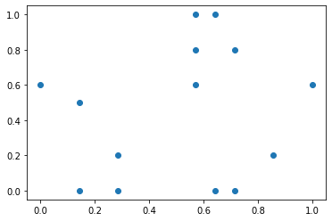

```python
# Affichage des points après normalisation:

data_norm = normalisation(data_desc)

plt.scatter(data_norm[:,0],data_norm[:,1])
```

**[Q]** Ecrire la fonction `dist_vect()` qui calcule la distance euclidienne entre deux vecteurs représenté sous forme d'`array`.

```python
dist_vect(data_norm[0,:],data_norm[1,:])
```

```
0.17437936593905287
```

### Calcul de centroides

**[Q]** Ecrire la fonction `centroide()` qui, étant un ensemble d'exemples, contenant au moins 2 exemples donné sous la forme d'un array rend leur centroide (sous la forme d'un array).

```python
print("Ensemble d'exemples: \n",data_norm[0:2,:])

print("Centroide correspondant:\n",centroide(data_norm[0:2,:]))
```

```
Ensemble d'exemples:
 [[0.         0.6       ]
 [0.14285714 0.5       ]]
Centroide correspondant:
 [0.07142857 0.55      ]
```

```python
centroide(data_norm)
```

```
array([0.51020408, 0.45      ])
```

Dans ce qui suit, on appelle "ensemble de centroides" un array contenant $K$ vecteurs de dimensions $p$.

## Partie 2: implémentation des k-moyennes

### Inertie d'un cluster

**[Q]** Ecrire la fonction `inertie_cluster` qui, étant donné un array contenant un ensemble d'exemples contenant au moins 2 exemples, rend la valeur de l'inertie de cet ensemble telle qu'elle a été définie dans le cours.

```python
np.set_printoptions(precision=3) # pour n'afficher que 3 chiffres au plus après la virgules...

print("inertie de l'ensemble :",inertie_cluster(data_norm))

np.set_printoptions(precision=8) # On remet comme c'était avant
```

```
centre: [0.51 0.45] 	Exemple:  [0.  0.6] 	distance =  0.283
centre: [0.51 0.45] 	Exemple:  [0.143 0.5  ] 	distance =  0.137
centre: [0.51 0.45] 	Exemple:  [0.143 0.   ] 	distance =  0.337
centre: [0.51 0.45] 	Exemple:  [0.286 0.   ] 	distance =  0.253
centre: [0.51 0.45] 	Exemple:  [0.286 0.2  ] 	distance =  0.113
centre: [0.51 0.45] 	Exemple:  [0.571 0.6  ] 	distance =  0.026
centre: [0.51 0.45] 	Exemple:  [0.571 0.8  ] 	distance =  0.126
centre: [0.51 0.45] 	Exemple:  [0.571 1.   ] 	distance =  0.306
centre: [0.51 0.45] 	Exemple:  [0.643 0.   ] 	distance =  0.220
centre: [0.51 0.45] 	Exemple:  [0.643 1.   ] 	distance =  0.320
centre: [0.51 0.45] 	Exemple:  [0.714 0.   ] 	distance =  0.244
centre: [0.51 0.45] 	Exemple:  [0.714 0.8  ] 	distance =  0.164
centre: [0.51 0.45] 	Exemple:  [0.857 0.2  ] 	distance =  0.183
centre: [0.51 0.45] 	Exemple:  [1.  0.6] 	distance =  0.262
inertie de l'ensemble : 2.975991253644316
```

```python
print("inertie de l'ensemble :",inertie_cluster(data_norm[0:2,:]))
```

```
inertie de l'ensemble : 0.01520408163265306
```

**[Q]** Ecrire la fonction `initialisation()` qui étant donné un entier $K>1$ et une base d'apprentissage de $n$ exemples rend un array contenant $K$ exemples tirés aléatoirement dans la base. On fait l'hypothèse que $K\leq n$.

*Remarque*: étudier les fonctions de la librairie random de Python...

```python
np.random.seed(42)   # supprimer cette ligne une fois la mise au point terminée

# Par exemple (mais vous ne devriez pas pouvoir retrouver exactement les mêmes !)
Centroides_test = initialisation(3,data_norm)
Centroides_test
```

```
Sélectionnés:  [9, 11, 0]
```

```
array([[0.64285714, 1.        ],
       [0.71428571, 0.8       ],
       [0.        , 0.6       ]])
```

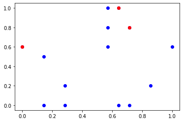

```python
plt.scatter(data_norm[:,0],data_norm[:,1],color='blue')
plt.scatter(Centroides_test[:,0],Centroides_test[:,1],color='red')
```

**[Q]** Ecrire la fonction `plus_proche()` qui, étant donné un exemple et un array contenant un ensemble de centroides, rend l'indice du array correspondant au centroide dont l'exemple est le plus proche. En cas d'égalité de distance, le centroide de plus petit indice est choisi.

```python
for i in range(0,len(data_norm)):
    pproche = plus_proche(data_norm[i,:],Centroides_test)
    print(pproche)
```

```
2
2
2
2
2
1
1
0
1
0
1
1
1
1
```

### Matrice d'affectation

Etant donné une base d'apprentissage, on peut représenter une partition de cette base en K clusters à l'aide d'une matrice U contenant n lignes (une par exemple) et K colonnes (une par cluster) et telle que les contraintes suivantes sont vérifiées:

- U[i,j] = 1 si l'exemple i appartient au cluster j
- U[i,j] = 0 si l'exemple i n'appartient pas au cluster j
- un exemple appartient à un et un seul cluster
- un cluster contient au moins un exemple

On appelle **matrice d'affectation** une telle matrice U.

**[Q]** Donner une expression mathématique (pas du Python) des 2 dernières contraintes que vérifie une matrice d'affectation.

(à faire sur feuille)

### Implémentation en Python

Nous utilisons un dictionnaire pour représenter d'une matrice d'affectation:

- les clés de ce dictionnaire correspondent aux $K$ indices des clusters
- les valeurs correspondent à des listes d'indices d'exemples (leur indice dans la base d'apprentissage)

Dans tout ce qui suit, une "matrice d'affectation" sera un tel dictionnaire.

**[Q]** Ecrire la fonction `affecte_cluster()` qui, étant donné une base d'apprentissage et un ensemble de $K$ centroïdes, rend la matrice d'affectation des exemples de la base aux clusters représentés par chaque centroïde.

```python
DictAffect = affecte_cluster(data_norm, Centroides_test)
DictAffect
```

```
{0: [7, 9], 1: [5, 6, 8, 10, 11, 12, 13], 2: [0, 1, 2, 3, 4]}
```

### Ensemble des centroides

Grâce à la matrice d'affectation, on peut maintenant trouver les nouveaux centroides. Ceux-ci sont déterminés en prenant les moyennes des ensembles des exemples qui sont affectés au même cluster.

**[Q]** Ecrire la fonction `nouveaux_centroides()` qui, étant donné une base d'apprentissage et une matrice d'affectation, rend l'ensemble des nouveaux centroides obtenus.

```python
data_norm[DictAffect[0]]
```

```
array([[0.57142857, 1.        ],
       [0.64285714, 1.        ]])
```

```python
centroide(data_norm[DictAffect[0]])
```

```
array([0.60714286, 1.        ])
```

```python
nouveaux_centroides(data_norm, DictAffect)
```

```
array([[0.60714286, 1.        ],
       [0.7244898 , 0.42857143],
       [0.17142857, 0.26      ]])
```

### Inertie globale d'une partition

**[Q]** En utilisant la fonction `inertie_cluster()`, écrire la fonction `inertie_globale()` qui, étant donné une base d'apprentissage et une matrice d'affectation, rend la valeur de l'inertie globale du partitionnement correspondant.

```python
np.set_printoptions(precision=3) # pour n'afficher que 3 chiffres au plus après la virgules...

print("Inertie globale: ",inertie_globale(data_norm,DictAffect))

np.set_printoptions(precision=8) # pour n'afficher que 3 chiffres au plus après la virgules...
```

```
Inertie globale:  1.2732099125364431
```

### Algorithme des K-moyennes

**[Q]** En utilisant les fonctions précédentes, implémenter l'algorithme des K-moyennes. Pour cela, écrire une fonction `kmoyennes()` qui prend en argument un entier $K>1$, une base d'apprentissage, ainsi que deux nombres: un réel *epsilon*$>0$ et un entier *iter_max*$>1$, et qui rend un ensemble de centroides et une matrice d'affectation.

Le réel *epsilon* sert de critère de convergence, et l'entier *iter_max* est utilisé pour fixer un nombre d'itérations maximal servant à arrêter le calcul.

```python
np.random.seed(42)   # supprimer cette ligne une fois la mise au point terminée

les_centres, l_affectation = kmoyennes(2, data_norm, 0.05, 100)

print("Affichage des centres: ",les_centres)
print("Affichage des affectations: ",l_affectation)
```

```
Sélectionnés:  [9, 11]
iteration  1  Inertie :  2.2482312925170067  Difference:  1.1982312925170067
iteration  2  Inertie :  1.5128163265306123  Difference:  0.7354149659863944
iteration  3  Inertie :  1.392091836734694  Difference:  0.12072448979591832
iteration  4  Inertie :  1.392091836734694  Difference:  0.0
Affichage des centres:  [[0.67857143 0.8       ]
 [0.38392857 0.1875    ]]
Affichage des affectations:  {0: [5, 6, 7, 9, 11, 13], 1: [0, 1, 2, 3, 4, 8, 10, 12]}
```

```python
np.random.seed(42)   # supprimer cette ligne une fois la mise au point terminée

les_centres, l_affectation = kmoyennes(3, data_norm, 0.05, 100)

print("Affichage des centres: ",les_centres)
print("Affichage des affectations: ",l_affectation)
```

```
Sélectionnés:  [9, 11, 0]
iteration  1  Inertie :  1.2732099125364431  Difference:  0.22320991253644307
iteration  2  Inertie :  0.9095408163265304  Difference:  0.3636690962099127
iteration  3  Inertie :  0.8127244897959183  Difference:  0.09681632653061212
iteration  4  Inertie :  0.8127244897959183  Difference:  0.0
Affichage des centres:  [[0.61428571 0.84      ]
 [0.80357143 0.2       ]
 [0.17142857 0.26      ]]
Affichage des affectations:  {0: [5, 6, 7, 9, 11], 1: [8, 10, 12, 13], 2: [0, 1, 2, 3, 4]}
```

On peut réaliser un affichage couleur des centroïdes trouvés:

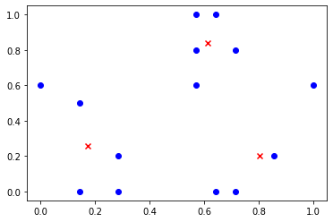

```python
plt.scatter(data_norm[:,0],data_norm[:,1],color='b')
plt.scatter(les_centres[:,0],les_centres[:,1],color='r',marker='x')
```

**[Q]** Ecrire la fonction `affiche_resultat()` qui permet d'afficher le résultat de l'algorithme en utilisant des couleurs différentes pour les clusters trouvés (pour faire simple, on peut ne considèrer que le cas où K vaut 3).

*Remarque*: La librairie matplotlib permet de manipuler aisément des couleurs: http://matplotlib.org/api/cm_api.html

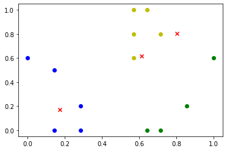

```python
affiche_resultat(data_norm,les_centres,l_affectation)
```

### Expérimentations

**[Q]** Expérimenter l'algorithme des k-moyennes sur les données. Etudier l'impact du choix de $K$ sur l'inertie globale finale. Faire de même en relançant plusieurs fois l'algorithme avec la même valeur de $K$, en modifiant la valeur de epsilon ou de max_iter, etc.

## Questions de cours (à faire sur feuille)

Pour vous entraîner sans machine...

**[Q]** On considère un ensemble fini $U$ d'éléments.

- donner la fonction caractéristique de $U$
- donner la fonction caractéristique de l'ensemble vide
- soit $E$ et $F$ deux sous-ensembles de $U$ définis par leurs fonctions caractéristiques $\chi_E$ et $\chi_F$. En déduire les fonctions caractéristiques de $E\cup F$, de $E\cap F$ et de $E^{c}$. *(indice: penser au min et au max)*

**[Q]** Rappeler la définition d'une partition $P$ d'un ensemble $X$ en $K$ sous-ensembles.

**[Q]** Appliquer, à la main, l'algorithme des K-moyennes sur les données fournies sur le transparent 8 du cours 9 en utilisant d'abord $K=2$, puis $K=3$. Dans chacun des cas, réaliser au maximum 10 itérations de l'algorithme ($t_{max}=10$). Comparer les résultats obtenus.